# Fuel Prices Across Auckland: A Visual Data Story

## Why observe fuel prices?

Fuel prices are an important part of everyday living costs in New Zealand. In this project, I used the Gaspy mobile app to observe and record the prices of 91 petrol, 95 petrol, and diesel across several Auckland areas.

The data was collected during morning, afternoon, and evening observations. Additional area information was included in the Google Form to compare regional differences in fuel prices across Auckland.

## Comparing the three fuel types

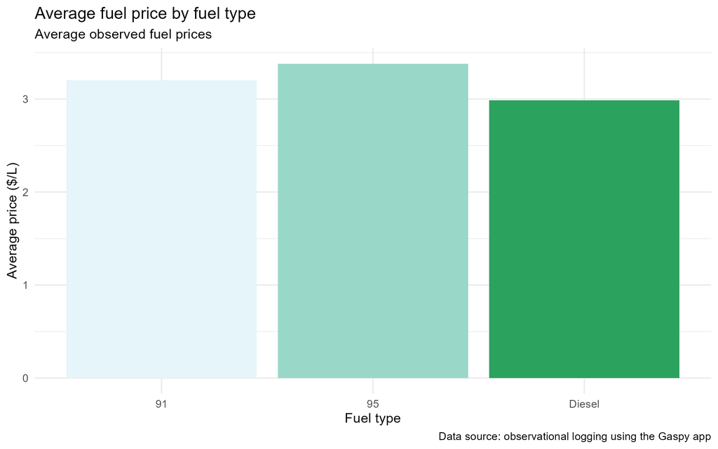

Average fuel price by fuel type

This visualisation compares the average observed fuel prices for the three fuel types. The results show that 95 petrol consistently remained more expensive than both 91 petrol and diesel.

Using a bar chart makes it easier to compare the average prices between categories.

## Fuel prices over time

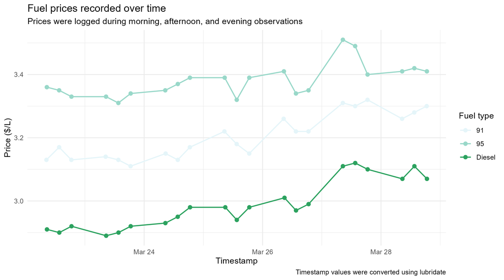

Fuel prices recorded over time

This plot uses timestamps converted with the lubridate package to explore how fuel prices changed over time.

Although the changes were relatively small, all three fuel types showed gradual increases during the observation period.

## Regional differences across Auckland

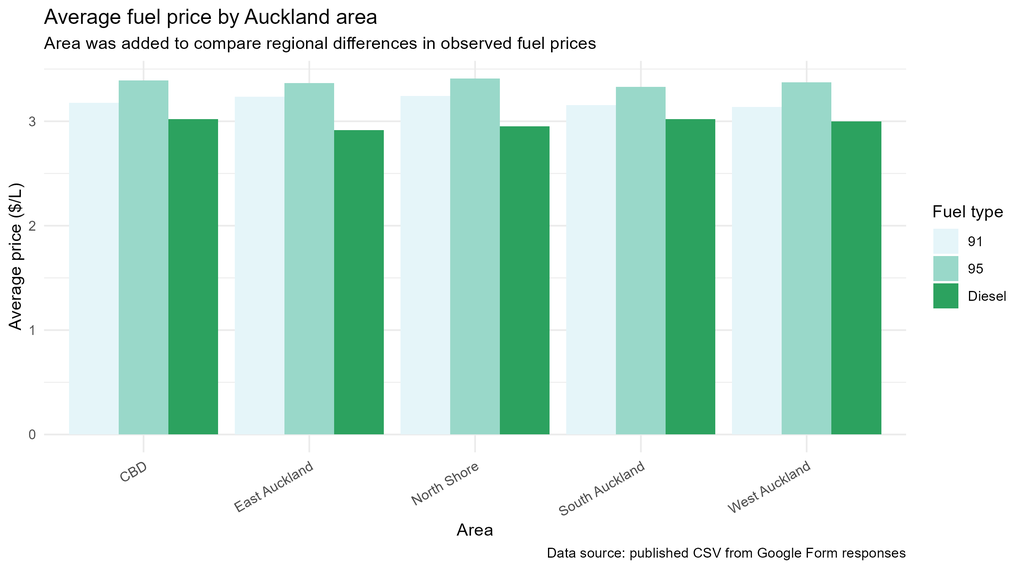

Average fuel price by Auckland area

Area was added as an additional variable to compare regional fuel price differences.

Grouped bar charts were used to allow comparisons between both fuel type and location simultaneously.

## What does this data story show?

This visual data story demonstrates how observational logging and data visualisation can be used to communicate real-world cost patterns.

Using R, ggplot2, Google Forms, and GitHub Pages made it possible to transform simple observational data into a visual communication project that is both informative and visually consistent.